Marc Rexheuser  
Frachtmanagement + Datenanalyse  
0049.157.54090160 Email [LinkedIn](https://www.linkedin.com/in/marc-rexheuser/) en

# Einführung Dieselzuschlag, ja oder nein?

Ein Ladungsspediteur will die Wirkung der Dieselkosten auf die Frachtpreise untersuchen. Die Frachtpreise werden tagesaktuell bestimmt und schwanken stark. Die Dieselkosten unterliegen ebenso starken Schwankungen. Alle anderen Kosten der eingesetzten Fahrzeuge sind eher konstant. Können also die Schwankungen des Frachtpreises mit den Dieselkosten erklärt werden?

Klar ist, dass die Spotpreise zu einem guten Teil von den aktuellen Marktbedingungen abhängen. Es wird aber vermutet, dass auch die Dieselkosten die Variation des Frachtpreises beeinflussen. Doch wie groß ist dieser Einfluss? Sollten die Dieselkosten erheblichen Einfluss haben, wäre die Einführung eines Zuschlags sinnvoll. Der Spediteur kann sich gegen Kostensteigerungen absichern und der Versender bekommt den Dieselkostenanteil der Fracht idealerweise netto durchgereicht. Sinnvoll und fair für beide Seiten.

## Denkansatz und Datenaufbereitung

Treibt der Diesel nicht nur die LKW, sondern auch die Frachtraten an? Ein lineares Regressionsmodell soll Aufschluss geben. Frachtpreis und Dieselkosten breche ich hierfür auf den Kilometer runter, unter Berücksichtigung von LKW-Kapazität und Ladevolumen der Sendung.

Die Transaktionsrohdaten beinhalten weder Transportentfernungen, noch Dieselpreisinformationen. Beide Variablen hole ich mir also von externen Datenquellen. Die Transportentfernungen zu jeder einzelnen Sendung ziehe ich automatisiert über die Google Geo-location Schnittstelle. Und die historischen Treibstoffpreise für LKW-Diesel lade ich von der Website des Mineralölwirtschaftsverbandes runter.

## Lösung Teil 1

Die Variablen *Mittler Frachtpreis/km* und *Dieselkosten/km* wurden jeder einzelnen Sendung zugeordnet - auf Basis der jeweiligen Postleitzahlgebiete von Absender/Empfänger Relationen. Die Darstellung *aller* Sendungen anhand dieser Variablen ergibt untenstehendes Bild. Ein Punktediagramm wäre auf Grund der hohen Sendungszahl unübersichtlich. Die nun vorliegende Dichte- oder Heatmap zeigt deutlich, wie die Sendungen verteilt sind.

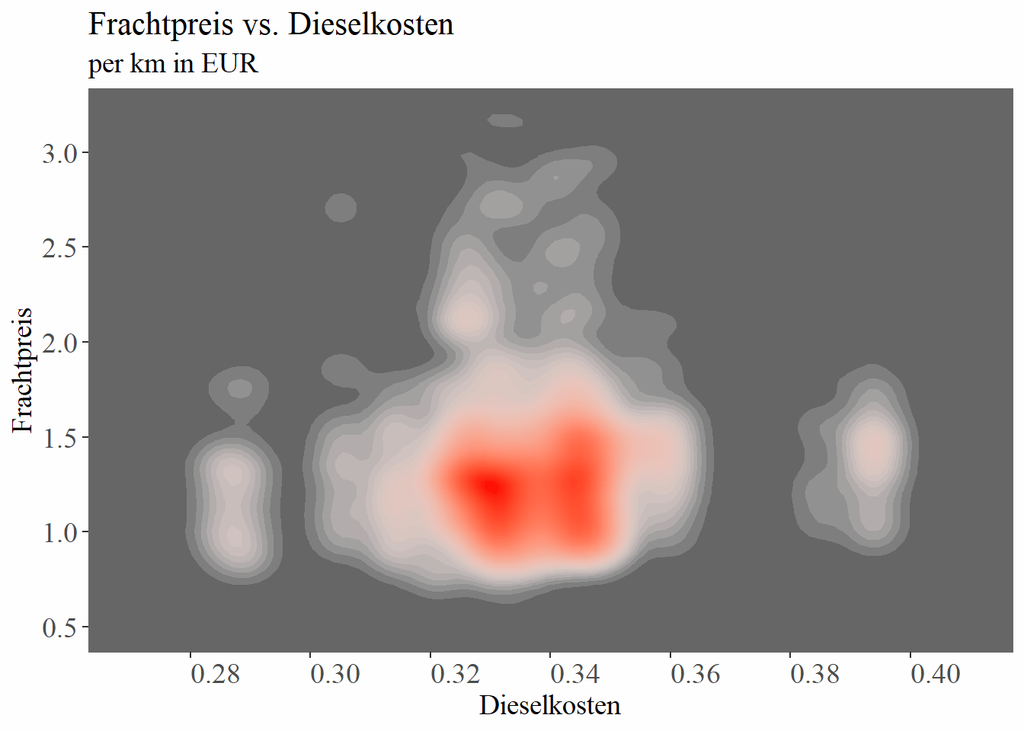

Das Diagramm überrascht. Mit bloßem Auge ist kein linearer Zusammenhang zwischen Dieselkosten und Frachtpreis erkennbar. Folglich wären die Dieselkosten keine Erklärung für die Frachtpreisschwankungen. Die Berechnung des Bestimmtheitsmaßes bestätigt diese Annahme: R²=0,0006. Die folgende Grafik zeigt, dass auch innerhalb der einzelnen untersuchten Jahre kein linearer Zusammenhang erkennbar ist.

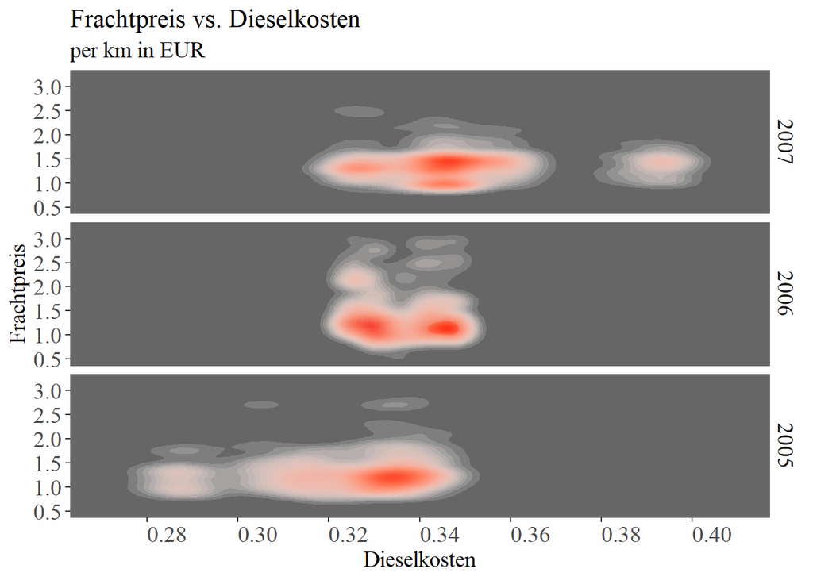

Interessant: Verglichen mit dem Jahr 2007 war die Fluktuation der Frachtpreise in 2006 extrem groß; bei nur geringer Bandbreite der Dieselkosten. 2005 und 2007 zeigen eine große Bandbreite der Dieselkosten in jeweils unterschiedlicher Richtung - bei weniger Frachtpreisfluktuation als in 2006.

## Lösung Teil 2

*Tonnenkilometer* sind das klassische Leistungsmaß im Transportsektor. Hier können sie aber nur 56 % der Variation des Frachtpreises erklären (R²=0,56). Es bleiben also 44 % der Frachtpreisschwankungen unerklärt. Für mehr Durchblick bringe ich die Zeitkomponente in die grafische Darstellung ein.

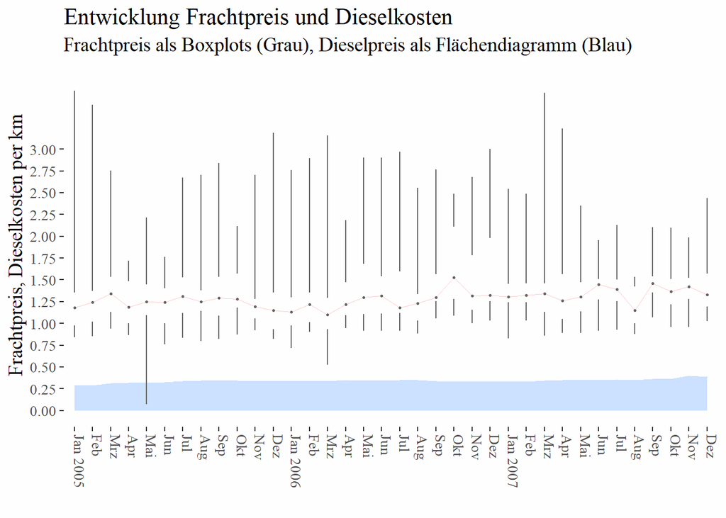

Hinweis zur Grafik: Der Punkt zeigt den mittleren Frachtpreis (Median), der untere Strich das untere Quartil und der obere Strich das obere Quartil aller Frachtpreise. Zwischen Punkt und Beginn der Striche liegen also 50 % aller Frachtpreise.

Nicht nur der mittlere Frachtpreis, sondern auch das Preisband fluktuiert extrem. Relativ schmal war es im Februar 2007 (50 % aller Frachtpreise zwischen EUR 1,24 - 1,39/km), besonders breit im Oktober 2006 (EUR 1,20 - 2,11/km). Bemerkenswert auch der Preisabsturz im August 2007: von EUR 1,39 auf 1,14/km. Industriebetriebe im untersuchten Fahrtgebiet schließen in diesem Monat. Also ein deutlicher Hinweis auf einen saisonalen Preistreiber.

In Monaten mit Dieselpreissteigerungen wurden mehrheitlich auch höhere Frachtpreise erzielt. In vier von 35 Monaten gelang das nicht, sh. folgende Grafik.

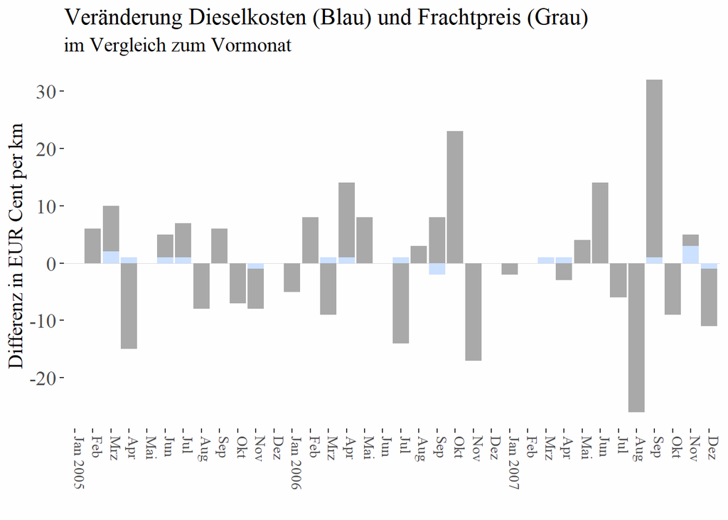

Nachfolgend der Dieselkostenanteil am Frachterlös. Es besteht das Risiko negativer Deckungsbeiträge bei überdurchschnittlich hohem Anteil. Beispielsweise im Zeitraum von Juli 2005 bis Mai 2006

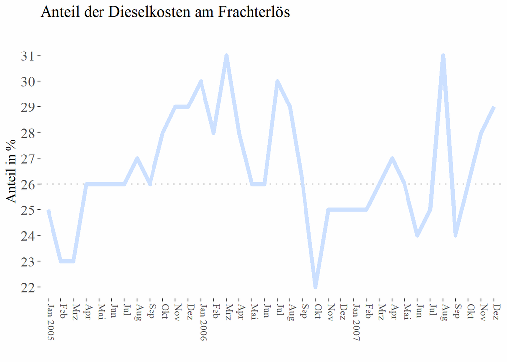

## Fazit

Ein Dieselzuschlag würde den Dieselkostenanteil für den Spediteur zwar absichern. Doch die Analyse zeigt: In diesem Spotmarkt ist der Frachtpreis durch Laderaumangebot und -nachfrage vorgegeben. Die Dieselkosten sind für die Preisbildung im Tagesgeschäft irrelevant. Es ist also zumindest aus Wettbewerbssicht *nicht* sinnvoll einen Dieselzuschlag einzuführen. Für den Verlader wäre es fair. Für den Spediteur würde es nur unnötige Transparenz, Wettbewerbsnachteile und aufwendigere Administration nach sich ziehen.

Um frühzeitig finanzielle Risiken abzusehen und abzuwenden, geht es vielmehr darum Muster im Markt zu erkennen. Zur Erkennung dieser Muster liefert die Analyse erste Anhaltspunkte - beispielsweise mit dem Aufzeigen saisonaler Schwankungen.